# cbg-priors

mht

February 25, 2015

```r
setwd("~/Documents/research/generics/cbg2010-replication/analysis")
d<-read.table('../data/cbgR-exp11-trials.tsv',header=T)
de<-read.table('../data/cbgR-exp11e-trials.tsv',header=T)
de$workerid<-de$workerid+length(unique(d$workerid))
d<-rbind(d,de)

d$item <- paste(d$stim_color,d$stim_part,sep="_")
table(d$stim_type,d$item)
```

```
##
##                   blue_ears blue_scales blue_teeth copper_fur copper_spots
##   bare                    5           9          8          5            7
##   danger-distinct        13           7         11          8            2
##   nondistinctive          8           6          5         14            9
##
##                   copper_stripes gold_feathers gold_spots gold_stripes
##   bare                         2             3         10            3
##   danger-distinct              3             8          4            4
##   nondistinctive               8             8          8            6
##
##                   green_shells green_tails green_teeth orange_ears
##   bare                       6           6          10          10
##   danger-distinct            6           9           2           9
##   nondistinctive             6           8           4           6
##
##                   orange_shells orange_tails pink_ears pink_legs
##   bare                        9            3         5         2
##   danger-distinct             7            4         9         9
##   nondistinctive              4            6         7         7
##
##                   pink_teeth purple_feathers purple_shells purple_tails
##   bare                     9               5            16            8
##   danger-distinct          5               7            10            8
##   nondistinctive           6               4             8            4
##
##                   red_feathers red_scales red_spots silver_fur silver_legs
##   bare                       7          6        11         10           9
##   danger-distinct            7          8         6          5           9
##   nondistinctive             7          5         5          8           8
##
##                   silver_stripes yellow_fur yellow_legs yellow_scales
##   bare                         3          4           5             4
##   danger-distinct              4          6           7             3
##   nondistinctive               9          3           7             6
```

```r
table(d$stim_type,d$stim_part)
```

```
##
##                   ears feathers fur legs scales shells spots stripes tails
##   bare              20       15  19   16     19     31    28       8    17
##   danger-distinct   31       22  19   25     18     23    12      11    21
##   nondistinctive    21       19  25   22     17     18    22      23    18
##
##                   teeth
##   bare               27
##   danger-distinct    18
##   nondistinctive     15
```

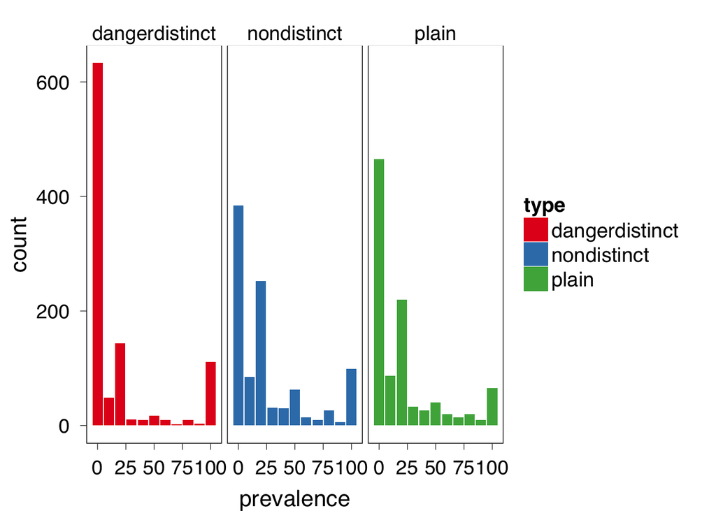

```r
d.tidy<-d %>%
  select(workerid,rt,trial_num,
              response0,response1,response2,response3,response4,
              stim_type) %>%
  rename(context=stim_type, trial=trial_num) %>%
  gather(option,value,-workerid,-rt,-context,-trial)%>%
  mutate(roundval=round(value/10)*10)


d.tidy0<-data.frame(table(filter(d.tidy,context=='bare')$roundval),
           table(filter(d.tidy,context=='danger-distinct')$roundval),
           table(filter(d.tidy,context=='nondistinctive')$roundval)) %>%
  select(Var1,Freq,Freq.1,Freq.2) %>%
  rename(prev=Var1,
         plain = Freq,
         dangerdistinct = Freq.1,
         nondistinct = Freq.2) %>%
  gather(type, value, -prev) %>%
  mutate(prev = to.n(prev))


d.tidy0$type<-factor(d.tidy0$type,
                       levels=c("dangerdistinct",
                                "nondistinct",
                                "plain"))

ggplot(d.tidy0, aes(x=prev, y=value, fill=type))+
  geom_bar(stat='identity', position=position_dodge())+
  facet_wrap(~type)+
  scale_fill_brewer(type='qual',palette='Set1')+
  xlab("prevalence")+
  ylab("count")
```

```r
# d.tidy$context<-factor(d.tidy$context,
#                        levels=c("danger-distinct",
#                                 "nondistinctive",
#                                 "bare"),
#                         labels=c("dangerous & distinctive",
#                                  "nondistinctive & irrelevant",
#                                  "plain"))
# ggplot(d.tidy,aes(x=value,fill=context))+
#   geom_histogram(binwidth=1)+
#   facet_wrap(~context)+
#   guides(fill=F)+
#   scale_fill_brewer(type='qual',palette=6)+
#   xlab('prevalence')+
#   ggtitle('human elicited prior distribution')



#
# ddply(d.tidy, .(context), summarise,
#       median = mean(value))
#
#
#
#
# dip.test(subset(d.tidy,context=='plain')$value)
# dip.test(subset(d.tidy,context=="nondistinctive & irrelevant")$value)
# dip.test(subset(d.tidy,context=='dangerous & distinctive')$value)
#
#
# contrasts(d.tidy$context)<-cbind(dd = c(-2,1,1), ni = c(0, 1, -1))
# contrasts(d.tidy$context)<-cbind(dd = c(1,0,-1), ni = c(-1, 2, -1))
#
# rs<-lmer(value ~ context + (1 | workerid), data=d.tidy)
# summary(rs)
#
# wilcox.test(value ~ context,
#             data = subset(d.tidy, context!="nondistinctive & irrelevant"))
#
# wilcox.test(value ~ context,
#             data = subset(d.tidy, context!='dangerous & distinctive'))
#
# wilcox.test(value ~ context,
#             data = subset(d.tidy, context!='plain'))
#
# kruskal.test(value ~ context, data = d.tidy)
#
# ks.test(subset(d.tidy,context=='plain')$value,
#         subset(d.tidy,context=='dangerous & distinctive')$value)
#
# ks.test(subset(d.tidy,context=="nondistinctive & irrelevant")$value,
#         subset(d.tidy,context=='dangerous & distinctive')$value)
#
# ks.test(subset(d.tidy,context=='plain')$value,
#         subset(d.tidy,context=="nondistinctive & irrelevant")$value)
```

# Distinctive manipulation check

Does distinctive imply taboo? That is, if you rate one animal as having it, do you set all the others to 0? (compare with other types)

```
## stat_bin: binwidth defaulted to range/30. Use 'binwidth = x' to adjust this.
## stat_bin: binwidth defaulted to range/30. Use 'binwidth = x' to adjust this.
## stat_bin: binwidth defaulted to range/30. Use 'binwidth = x' to adjust this.
```

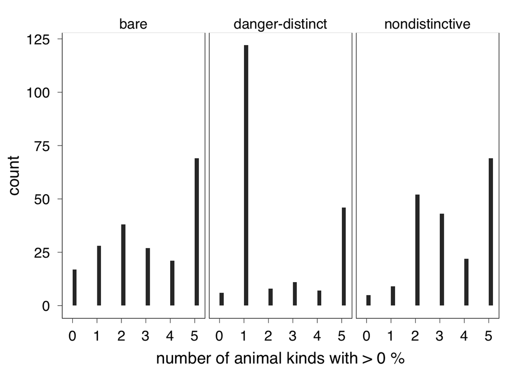

```r
d.taboo<-d.tidy %>%
  group_by(workerid,trial, context) %>%
  summarise(n.positive = sum(value>0))

qplot(data=d.taboo,x=n.positive,geom='histogram')+
  facet_wrap(~context)+
  xlab("number of animal kinds with > 0 %")
```

# Compliance

How much do subjects put for each trial? (What do their numbers sum to?)

“onedone” here means subject puts 100 for one of the animals, and all 0s otherwise

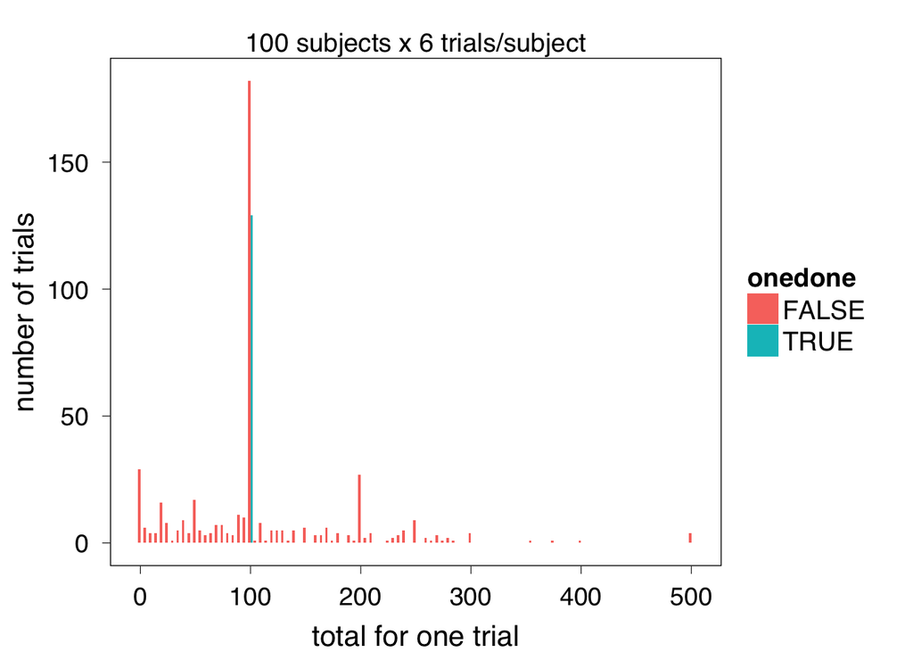

```r
d.subj <- d.tidy %>%
  group_by(workerid, trial) %>%
  summarise(total = round(sum(value)/5)*5, # rounds to the nearest 5
            max = max(value),
            min = min(value)) %>%
  mutate(onedone=((total==100)&(max==100)))

d.subj0<-data.frame(table(d.subj$total,d.subj$onedone)) %>%
  mutate(total = to.n(Var1)) %>%
  rename(onedone = Var2)

ggplot(data=d.subj0,aes(x=total,y=Freq, fill=onedone))+
  geom_bar(stat='identity',position=position_dodge())+
  xlab("total for one trial")+
  ylab("number of trials")+
  ggtitle("100 subjects x 6 trials/subject")
```

How many people make their responses add to 100?

```r
d.bad<-d.subj %>% filter((total==100)&(onedone==F))

print("number of subjects who do this 100 behavior at least once")
```

```
## [1] "number of subjects who do this 100 behavior at least once"
```

```r
length(levels(factor(d.bad$workerid)))
```

```
## [1] 49
```

```r
print("total number of trials with this 100 behavior")
```

```
## [1] "total number of trials with this 100 behavior"
```

```r
length(d.bad$workerid)
```

```
## [1] 182
```

```
## stat_bin: binwidth defaulted to range/30. Use 'binwidth = x' to adjust this.
```

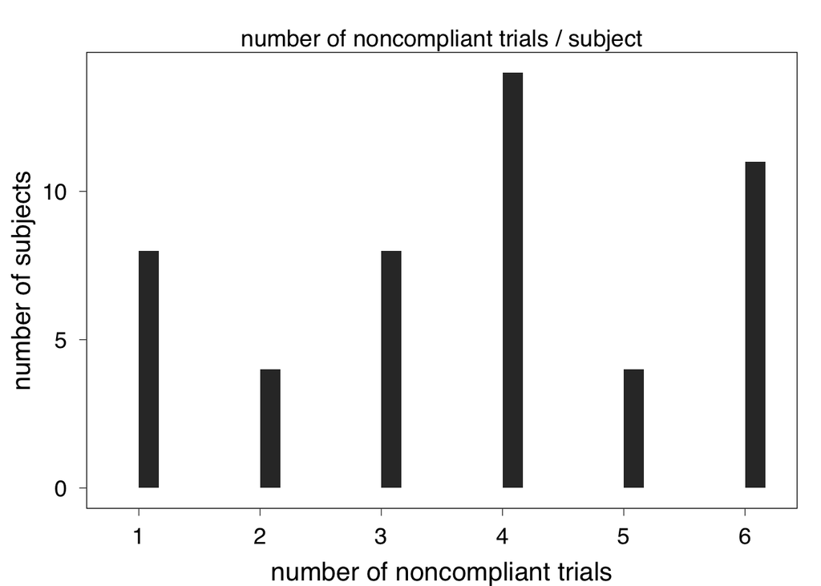

```r
qplot(data=data.frame(table(d.bad$workerid)), x=Freq, geom='histogram')+
  scale_x_continuous(breaks=seq(1,6,1))+
  ggtitle("number of noncompliant trials / subject")+
  xlab("number of noncompliant trials")+
  ylab("number of subjects")
```

```
## stat_bin: binwidth defaulted to range/30. Use 'binwidth = x' to adjust this.
```

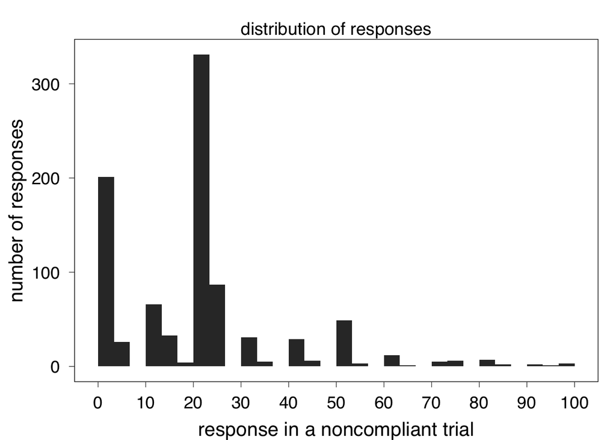

```r
d.bad<-d.bad %>% mutate(id = paste(workerid,trial))
d.tidy<-d.tidy%>% mutate(id = paste(workerid,trial))

d.culprits<-d.tidy %>% filter(id%in%d.bad$id)

qplot(data=d.culprits, x=value, geom='histogram')+
  scale_x_continuous(breaks=seq(0,100,10), limits=c(0,100))+
  ggtitle("distribution of responses")+
  xlab("response in a noncompliant trial")+
  ylab("number of responses")
```

# Single response, free response prior

## Dangerous & Distinct, Nondistinct, Plain

```r
d<-read.csv('../data/cbg-prior1a-trials.csv',header=T)
d$item <- paste(d$stim_color,d$stim_part,sep="_")
table(d$stim_type,d$item)
```

```
##
##                   blue_ears blue_scales blue_teeth copper_fur copper_spots
##   bare                   12           9          9          9            9
##   danger-distinct        10          12         10         11           12
##   nondistinctive          8           9         11         10            9
##
##                   copper_stripes gold_feathers gold_spots gold_stripes
##   bare                        10            10          9           12
##   danger-distinct             15            10         13            9
##   nondistinctive               5            10          8            9
##
##                   green_shells green_tails green_teeth orange_ears
##   bare                       9          10          15          11
##   danger-distinct           12           7           8           8
##   nondistinctive             9          13           7          11
##
##                   orange_shells orange_tails pink_ears pink_legs
##   bare                       12            7         9         8
##   danger-distinct             8            8         9        13
##   nondistinctive             10           15        12         9
##
##                   pink_teeth purple_feathers purple_shells purple_tails
##   bare                     7              13             6            8
##   danger-distinct          9               9            12           12
##   nondistinctive          14               8            12           10
##
##                   red_feathers red_scales red_spots silver_fur silver_legs
##   bare                       6         10         8         12           9
##   danger-distinct           12         10         5         10           7
##   nondistinctive            12         10        17          8          14
##
##                   silver_stripes yellow_fur yellow_legs yellow_scales
##   bare                        13         10          17            11
##   danger-distinct              8         11          11             9
##   nondistinctive               9          9           2            10
```

```r
table(d$stim_type,d$stim_part)
```

```
##
##                   ears feathers fur legs scales shells spots stripes tails
##   bare              32       29  31   34     30     27    26      35    25
##   danger-distinct   27       31  32   31     31     32    30      32    27
##   nondistinctive    31       30  27   25     29     31    34      23    38
##
##                   teeth
##   bare               31
##   danger-distinct    27
##   nondistinctive     32
```

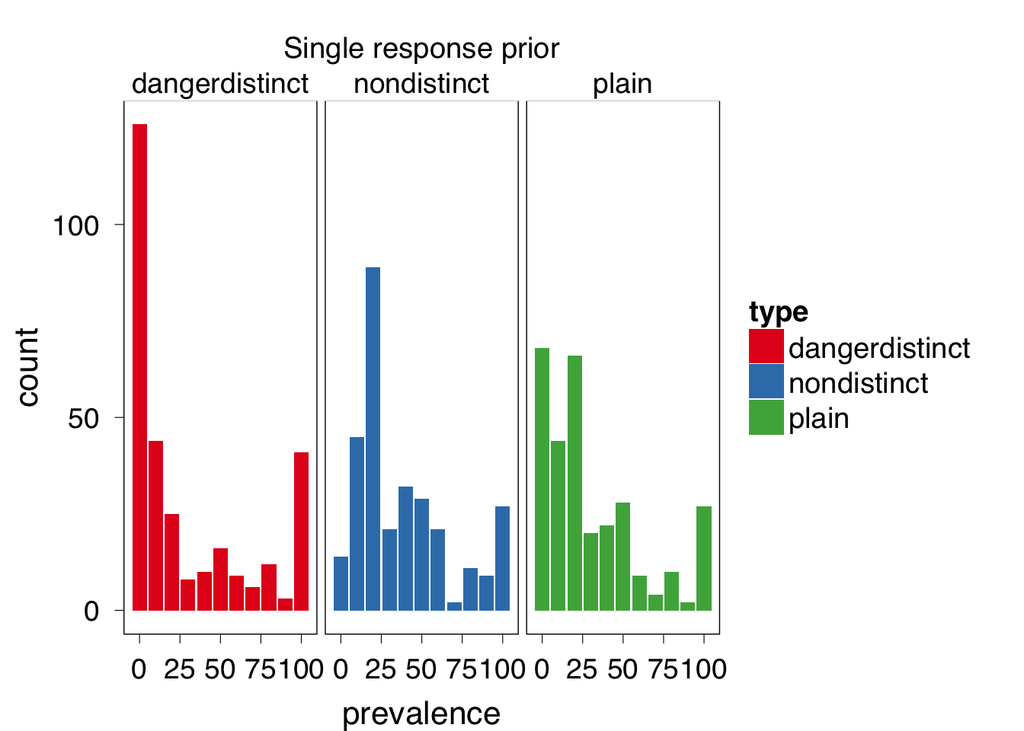

```r
d.tidy<-d%>%select(workerid,rt,response0,stim_type) %>%
  rename(context=stim_type) %>%
  gather(option,value,-workerid,-rt,-context)%>%
  mutate(roundval=round(value/10)*10)


d.tidy0<-data.frame(table(filter(d.tidy,context=='bare')$roundval),
           table(filter(d.tidy,context=='danger-distinct')$roundval),
           table(filter(d.tidy,context=='nondistinctive')$roundval)) %>%
  select(Var1,Freq,Freq.1,Freq.2) %>%
  rename(prev=Var1,
         plain = Freq,
         dangerdistinct = Freq.1,
         nondistinct = Freq.2) %>%
  gather(type, value, -prev) %>%
  mutate(prev = to.n(prev))


d.tidy0$type<-factor(d.tidy0$type,
                       levels=c("dangerdistinct",
                                "nondistinct",
                                "plain"))

ggplot(d.tidy0, aes(x=prev, y=value, fill=type))+
  geom_bar(stat='identity', position=position_dodge())+
  facet_wrap(~type)+
  scale_fill_brewer(type='qual',palette='Set1')+
  xlab("prevalence")+
  ylab("count")+
  ggtitle("Single response prior")
```

## Danger, Distinct, Plain

```r
d<-read.csv('../data/cbg-prior1b-trials.csv',header=T)
d$item <- paste(d$stim_color,d$stim_part,sep="_")
table(d$stim_type,d$item)
```

```
##
##            blue_ears blue_scales blue_teeth copper_fur copper_spots
##   bare             9          13         12          9           11
##   danger           6          10          7         10           16
##   distinct        15           7         11         11            3
##
##            copper_stripes gold_feathers gold_spots gold_stripes
##   bare                 12            12          8            6
##   danger               12             7         12            8
##   distinct              6            11         10           16
##
##            green_shells green_tails green_teeth orange_ears orange_shells
##   bare               13           5           7           6             4
##   danger              9          14          14           9             9
##   distinct            8          11           9          15            17
##
##            orange_tails pink_ears pink_legs pink_teeth purple_feathers
##   bare               10        15        11         13              12
##   danger             11         8         7         11              11
##   distinct            9         7        12          6               7
##
##            purple_shells purple_tails red_feathers red_scales red_spots
##   bare                10            9            9         18        10
##   danger               7           13           12          6         9
##   distinct            13            8            9          6        11
##
##            silver_fur silver_legs silver_stripes yellow_fur yellow_legs
##   bare             10          11              9          9          11
##   danger           11          11             11         11           7
##   distinct          9           8             10         10          12
##
##            yellow_scales
##   bare                 6
##   danger              11
##   distinct            13
```

```r
table(d$stim_type,d$stim_part)
```

```
##
##            ears feathers fur legs scales shells spots stripes tails teeth
##   bare       30       33  28   33     37     27    29      27    24    32
##   danger     23       30  32   25     27     25    37      31    38    32
##   distinct   37       27  30   32     26     38    24      32    28    26
```

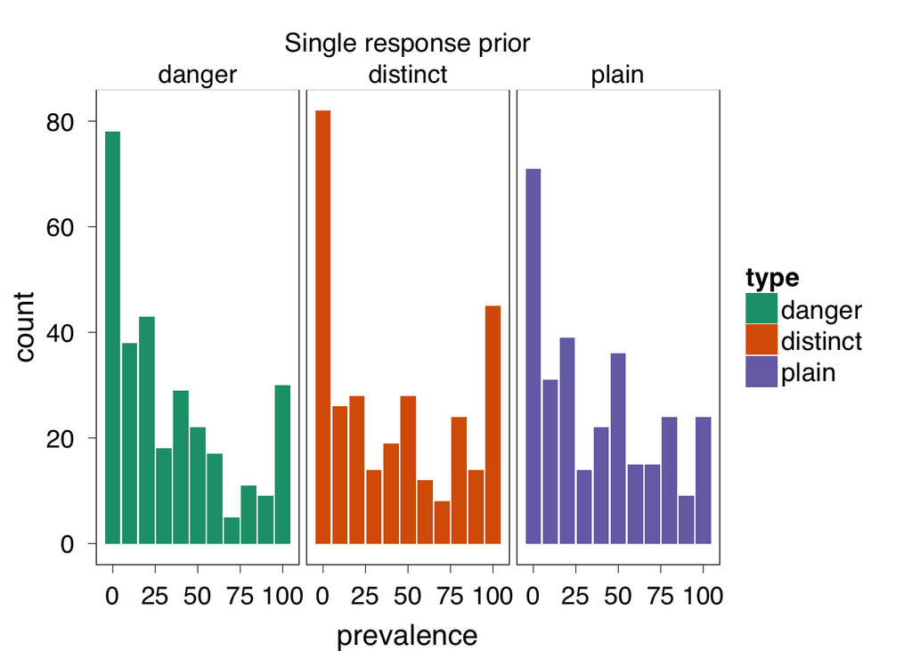

```r
d.tidy<-d%>%select(workerid,rt,response0,stim_type) %>%
  rename(context=stim_type) %>%
  gather(option,value,-workerid,-rt,-context)%>%
  mutate(roundval=round(value/10)*10)


d.tidy0<-data.frame(table(filter(d.tidy,context=='bare')$roundval),
           table(filter(d.tidy,context=='danger')$roundval),
           table(filter(d.tidy,context=='distinct')$roundval)) %>%
  select(Var1,Freq,Freq.1,Freq.2) %>%
  rename(prev=Var1,
         plain = Freq,
         danger = Freq.1,
         distinct = Freq.2) %>%
  gather(type, value, -prev) %>%
  mutate(prev = to.n(prev))


d.tidy0$type<-factor(d.tidy0$type,
                       levels=c("danger",
                                "distinct",
                                "plain"))

ggplot(d.tidy0, aes(x=prev, y=value, fill=type))+
  geom_bar(stat='identity', position=position_dodge())+
  facet_wrap(~type)+
  scale_fill_brewer(type='qual',palette='Dark2')+
  xlab("prevalence")+
  ylab("count")+
  ggtitle("Single response prior")
```

Binned histograms (garbage?)

```r
d<-read.csv('../data/cbg-prior2a-trials.csv',header=T)
d$item <- paste(d$color,d$part,sep="_")
table(d$context,d$item)
```

```
##
##                   blue_ears blue_scales blue_teeth copper_fur copper_spots
##   bare                    3           2          3          4            3
##   danger-distinct         2           9          4          5            3
##   nondistinctive          5           5          5          7            4
##
##                   copper_stripes gold_feathers gold_spots gold_stripes
##   bare                         3             1          5            2
##   danger-distinct              4             2          4            5
##   nondistinctive               2             9          3            5
##
##                   green_shells green_tails green_teeth orange_ears
##   bare                       5           3           7           6
##   danger-distinct            2           4           6           3
##   nondistinctive             5           6           4           2
##
##                   orange_shells orange_tails pink_ears pink_legs
##   bare                        3            5         4         1
##   danger-distinct             4            3         3         5
##   nondistinctive              3            5         7         3
##
##                   pink_teeth purple_feathers purple_shells purple_tails
##   bare                     3               5             4            7
##   danger-distinct          3               5             4            5
##   nondistinctive           2               1             0            5
##
##                   red_feathers red_scales red_spots silver_fur silver_legs
##   bare                       6          3         7          6           3
##   danger-distinct            3          4         1          5           6
##   nondistinctive             2          5         5          1           4
##
##                   silver_stripes yellow_fur yellow_legs yellow_scales
##   bare                         5          1           4             6
##   danger-distinct              5          5           5             1
##   nondistinctive               4          5           3             3
```

```r
table(d$context,d$part)
```

```
##
##                   ears feathers fur legs scales shells spots stripes tails
##   bare              13       12  11    8     11     12    15      10    15
##   danger-distinct    8       10  15   16     14     10     8      14    12
##   nondistinctive    14       12  13   10     13      8    12      11    16
##
##                   teeth
##   bare               13
##   danger-distinct    13
##   nondistinctive     11
```

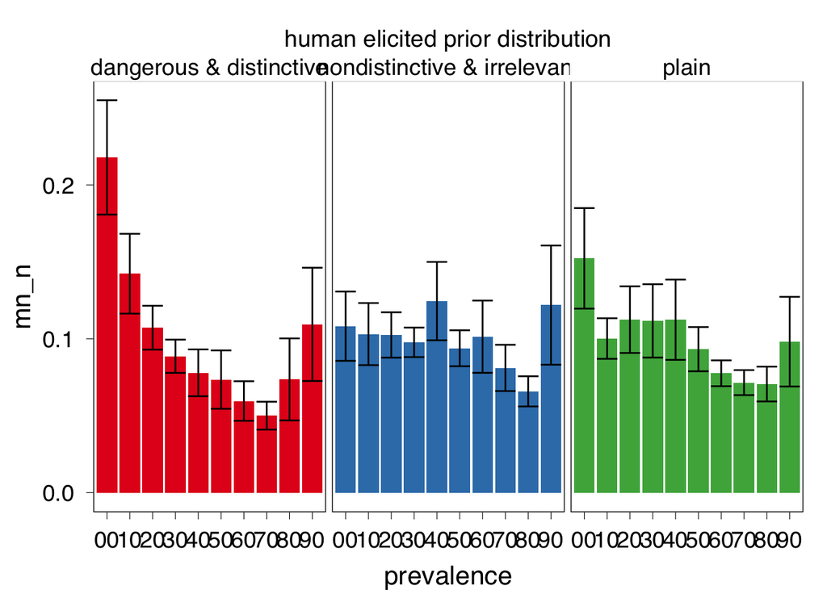

```r
#maybe?
## yes: the experiment allowed you to advance if you had clicked the last slider, but not any of the other ones
d[is.na(d)]<-0

d.tidy<-d %>%
  select(workerid,rt,context,item,starts_with("bin"),-binOrder) %>%
  gather(bin,value,-workerid,-rt,-context, -item) %>%
  group_by(workerid,item) %>%
  mutate(val_normed = value/sum(value)) %>%
  separate(bin, into=c("thing","bin"), by="_")

d.tidy$context<-factor(d.tidy$context,
                       levels=c("danger-distinct",
                                "nondistinctive",
                                "bare"),
                        labels=c("dangerous & distinctive",
                                 "nondistinctive & irrelevant",
                                 "plain"))
d.stats <- d.tidy %>%
  group_by(context,bin) %>%
  summarise(mn = mean(value,na.rm=T),
            sterr = sem(value),
            mn_n = mean(val_normed, na.rm=T),
            sterr_n = sem(val_normed))

ggplot(d.stats,aes(x=bin,y=mn_n,fill=context))+
  geom_bar(stat='identity')+
  geom_errorbar(aes(ymin=mn_n-1.96*sterr_n,ymax=mn_n+1.96*sterr_n))+
  facet_wrap(~context)+
  guides(fill=F)+
  scale_fill_brewer(type='qual',palette=6)+
  xlab('prevalence')+
  ggtitle('human elicited prior distribution')
```

# 10 numbers

## Dangerous & Distinct, Nondistinct, Plain

```r
d<-read.csv(file = '../data/cbg-prior3-trials.csv')
#head(d)
d.tidy3<- d%>%
  select(stim_type, starts_with("response"), workerid, trial_num) %>%
  rename(context = stim_type,
         trial = trial_num) %>%
  gather(key, value, -context, -workerid, -trial) %>%
    mutate(roundval=round(value/10)*10)

## add counts to certain bins to fill out responses
d.tidy3<-bind_rows(d.tidy3,
data.frame(workerid=1000, context='danger-distinct',item='blank',
           key='hand',value=c(70,90), roundval=c(70,90))
)
```

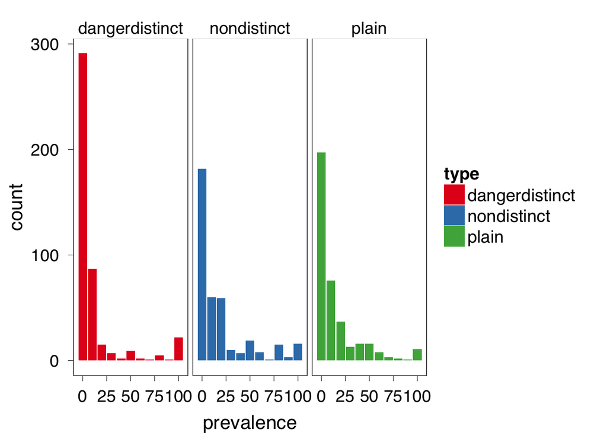

```r
d.tidy0<-data.frame(table(filter(d.tidy3,context=='bare')$roundval),
           table(filter(d.tidy3,context=='danger-distinct')$roundval),
           table(filter(d.tidy3,context=='nondistinctive')$roundval)) %>%
  select(Var1,Freq,Freq.1,Freq.2) %>%
  rename(prev=Var1,
         plain = Freq,
         dangerdistinct = Freq.1,
         nondistinct = Freq.2) %>%
  gather(type, value, -prev) %>%
  mutate(prev = to.n(prev))


d.tidy0$type<-factor(d.tidy0$type,
                       levels=c("dangerdistinct",
                                "nondistinct",
                                "plain"))

ggplot(d.tidy0, aes(x=prev, y=value, fill=type))+
  geom_bar(stat='identity', position=position_dodge())+
  facet_wrap(~type)+
  scale_fill_brewer(type='qual',palette='Set1')+
  xlab("prevalence")+
  ylab("count")
```

### Distinctive manipulation check

Does distinctive imply taboo? That is, if you rate one animal as having it, do you set all the others to 0? (compare with other types)

```
## stat_bin: binwidth defaulted to range/30. Use 'binwidth = x' to adjust this.
## stat_bin: binwidth defaulted to range/30. Use 'binwidth = x' to adjust this.
## stat_bin: binwidth defaulted to range/30. Use 'binwidth = x' to adjust this.
```

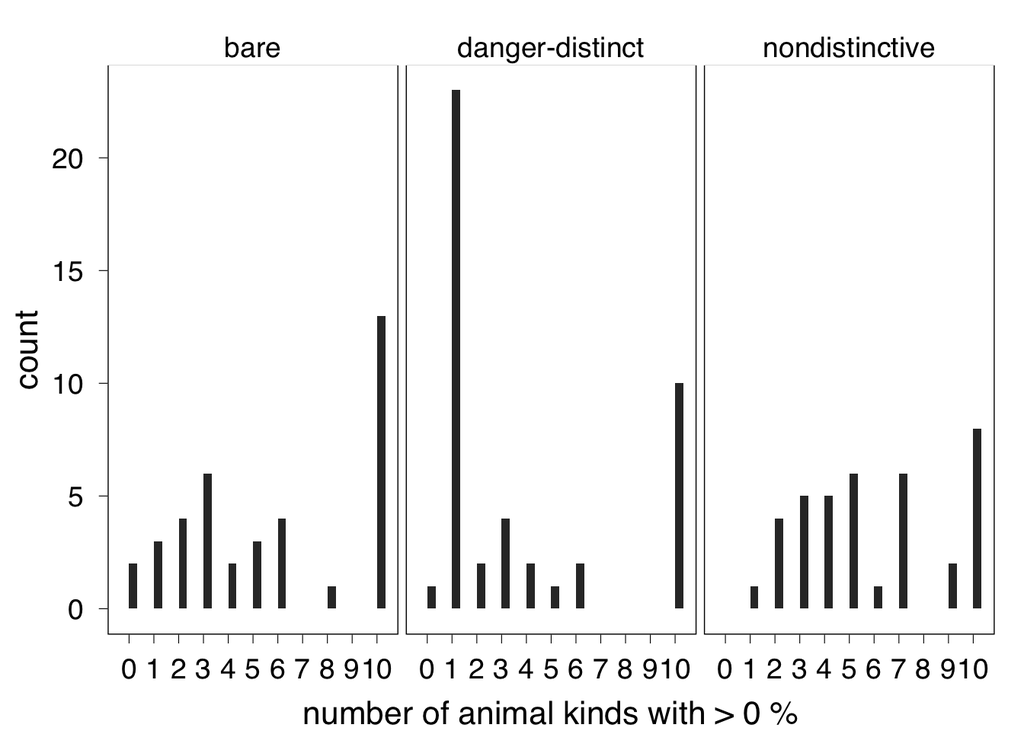

```r
d.taboo<-d.tidy3 %>%
  group_by(workerid,trial, context) %>%
  summarise(n.positive = sum(value>0))

qplot(data=d.taboo,x=n.positive,geom='histogram')+
  facet_wrap(~context)+
  xlab("number of animal kinds with > 0 %")+
  scale_x_continuous(breaks = 0:10)
```

### Compliance

How much do subjects put for each trial? (What do their numbers sum to?)

“onedone” here means subject puts 100 for one of the animals, and all 0s otherwise

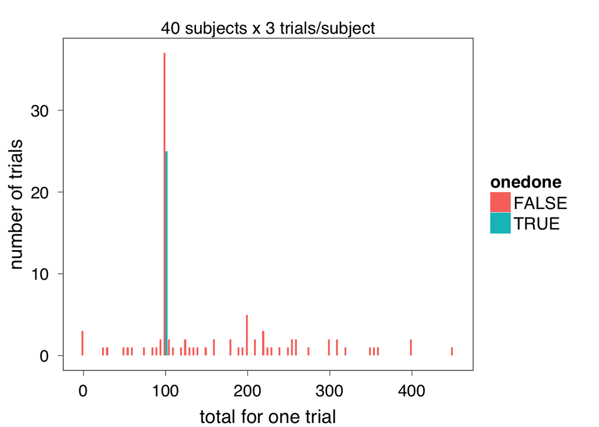

```r
d.subj <- d.tidy3 %>%
  group_by(workerid, trial) %>%
  summarise(total = round(sum(value)/5)*5, # rounds to the nearest 5
            max = max(value),
            min = min(value)) %>%
  mutate(onedone=((total==100)&(max==100)))

d.subj0<-data.frame(table(d.subj$total,d.subj$onedone)) %>%
  mutate(total = to.n(Var1)) %>%
  rename(onedone = Var2)

ggplot(data=d.subj0,aes(x=total,y=Freq, fill=onedone))+
  geom_bar(stat='identity',position=position_dodge())+
  xlab("total for one trial")+
  ylab("number of trials")+
  ggtitle("40 subjects x 3 trials/subject")
```

How many people make their responses add to 100?

```r
d.bad<-d.subj %>% filter((total==100)&(onedone==F))

print("number of subjects who do this 100 behavior at least once")
```

```
## [1] "number of subjects who do this 100 behavior at least once"
```

```r
length(levels(factor(d.bad$workerid)))
```

```
## [1] 18
```

```r
print("total number of trials with this 100 behavior")
```

```
## [1] "total number of trials with this 100 behavior"
```

```r
length(d.bad$workerid)
```

```
## [1] 37
```

```
## stat_bin: binwidth defaulted to range/30. Use 'binwidth = x' to adjust this.
```

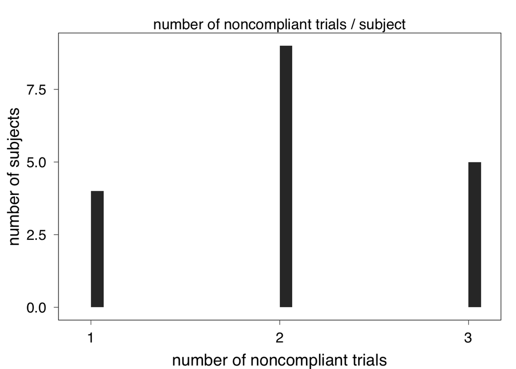

```r
qplot(data=data.frame(table(d.bad$workerid)), x=Freq, geom='histogram')+
  scale_x_continuous(breaks=seq(0:4))+
  ggtitle("number of noncompliant trials / subject")+
  xlab("number of noncompliant trials")+
  ylab("number of subjects")
```

```
## stat_bin: binwidth defaulted to range/30. Use 'binwidth = x' to adjust this.
```

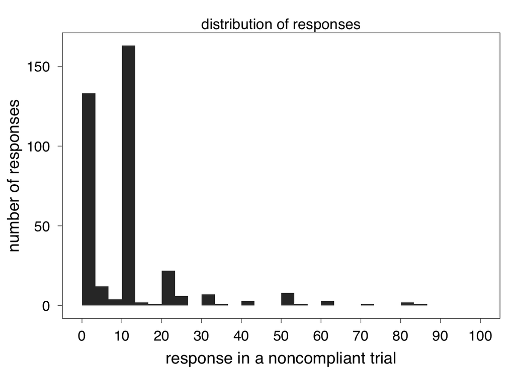

```r
d.bad<-d.bad %>% mutate(id = paste(workerid,trial))
d.tidy3<-d.tidy3%>% mutate(id = paste(workerid,trial))

d.culprits<-d.tidy3 %>% filter(id%in%d.bad$id)

qplot(data=d.culprits, x=value, geom='histogram')+
  scale_x_continuous(breaks=seq(0,100,10), limits=c(0,100))+
  ggtitle("distribution of responses")+
  xlab("response in a noncompliant trial")+
  ylab("number of responses")
```

# Prior 6: 10 state, separate danger / distinct

```r
d<-read.csv(file = '../data/cbg-prior6-trials.csv')

d$item<-paste(d$stim_color,d$stim_part,sep='_')
#head(d)
d.tidy6<- d%>%
  select(workerid,stim_type, item, starts_with("response"),trial_num) %>%
  rename(context = stim_type, trial=trial_num) %>%
  gather(key, value, -context, -item, -workerid, -trial) %>%
  #mutate(roundval=round(value/5)*5)
  mutate(roundval=round(value/10)*10)


d.tidy6<-bind_rows(d.tidy6,
data.frame(workerid=1000, context='danger',item='blank',key='hand',value=90, roundval=90)
)
```

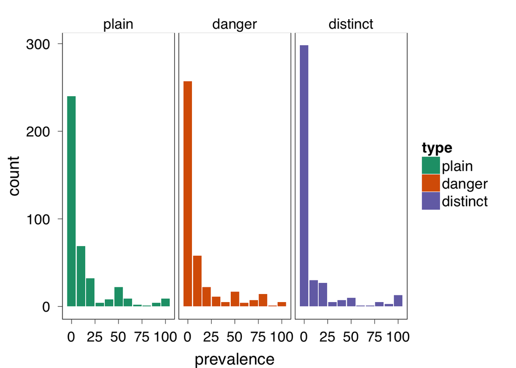

```r
d.tidy<-data.frame(table(filter(d.tidy6,context=='bare')$roundval),
           table(filter(d.tidy6,context=='danger')$roundval),
           table(filter(d.tidy6,context=='distinct')$roundval)) %>%
  select(Var1,Freq,Freq.1,Freq.2) %>%
  rename(prev=Var1,
         plain = Freq,
         danger = Freq.1,
         distinct = Freq.2) %>%
  gather(type, value, -prev) %>%
  mutate(prev = to.n(prev))

ggplot(d.tidy, aes(x=prev, y=value, fill=type))+
  geom_bar(stat='identity', position=position_dodge())+
  facet_wrap(~type)+
    scale_fill_brewer(type='qual',palette='Dark2')+
  xlab("prevalence")+
  ylab("count")
```

### Distinctive manipulation check

Does distinctive imply taboo? That is, if you rate one animal as having it, do you set all the others to 0? (compare with other types)

```
## stat_bin: binwidth defaulted to range/30. Use 'binwidth = x' to adjust this.
## stat_bin: binwidth defaulted to range/30. Use 'binwidth = x' to adjust this.
## stat_bin: binwidth defaulted to range/30. Use 'binwidth = x' to adjust this.
```

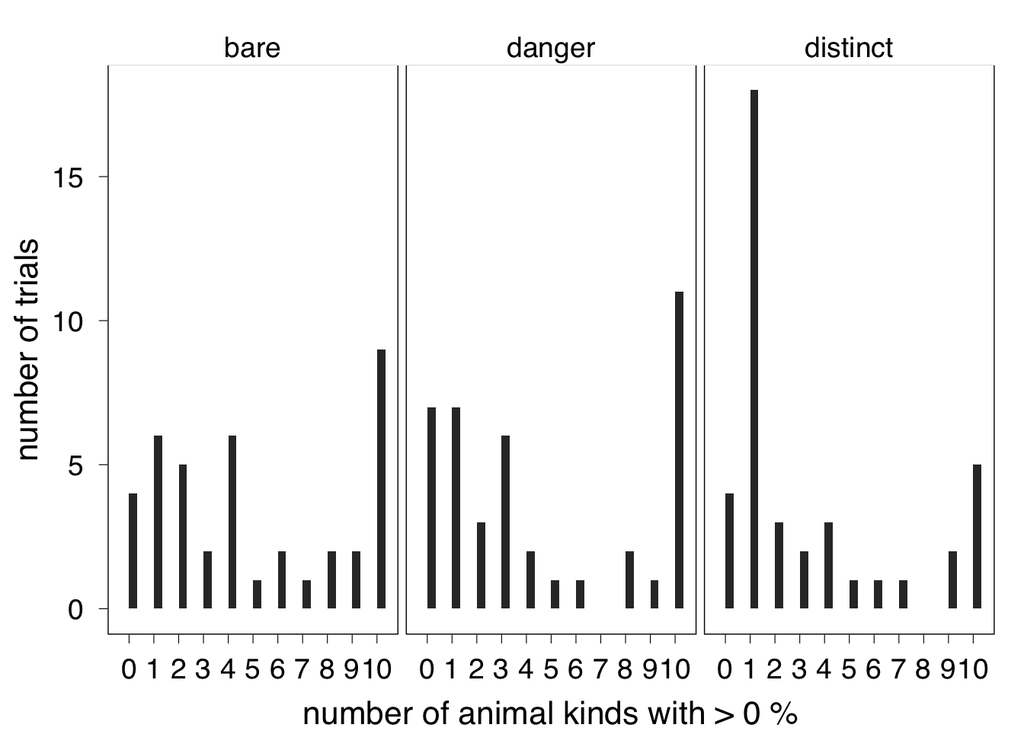

```r
d.taboo<-d.tidy6 %>%
  group_by(workerid,trial, context) %>%
  summarise(n.positive = sum(value>0))

qplot(data=d.taboo,x=n.positive,geom='histogram')+
  facet_wrap(~context)+
  xlab("number of animal kinds with > 0 %")+
  ylab("number of trials")+
  scale_x_continuous(breaks = 0:10)
```

### Compliance

How much do subjects put for each trial? (What do their numbers sum to?)

“onedone” here means subject puts 100 for one of the animals, and all 0s otherwise

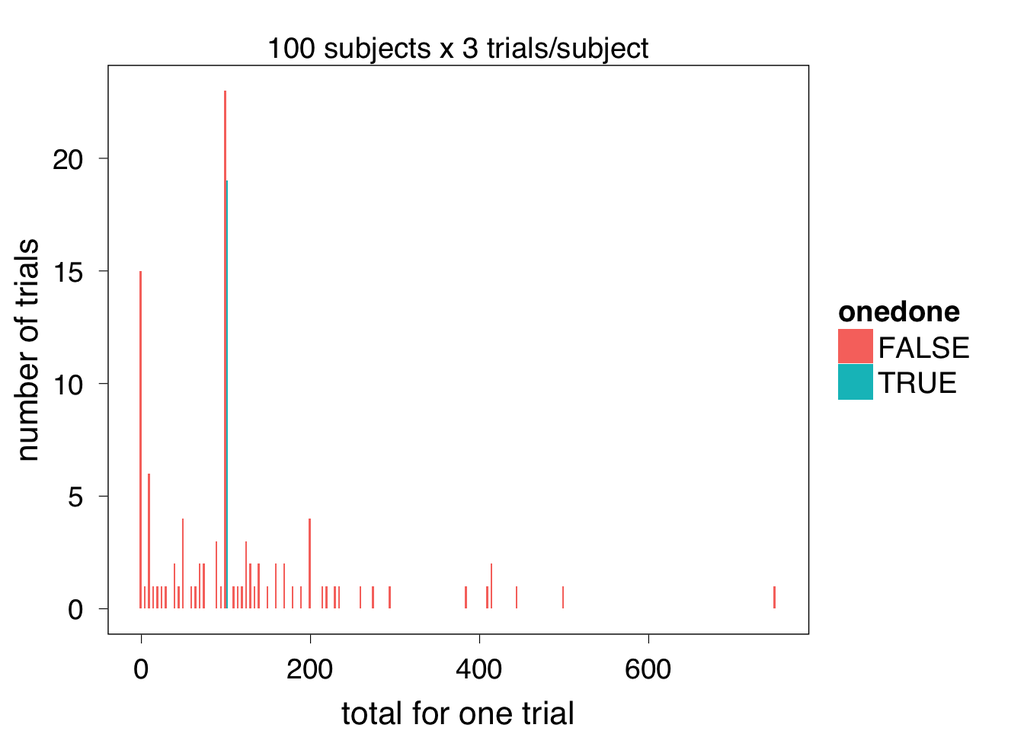

```r
d.subj <- d.tidy6 %>%
  group_by(workerid, trial) %>%
  summarise(total = round(sum(value)/5)*5, # rounds to the nearest 5
            max = max(value),
            min = min(value)) %>%
  mutate(onedone=((total==100)&(max==100)))

d.subj0<-data.frame(table(d.subj$total,d.subj$onedone)) %>%
  mutate(total = to.n(Var1)) %>%
  rename(onedone = Var2)

ggplot(data=d.subj0,aes(x=total,y=Freq, fill=onedone))+
  geom_bar(stat='identity',position=position_dodge())+
  xlab("total for one trial")+
  ylab("number of trials")+
  ggtitle("100 subjects x 3 trials/subject")
```

How many people make their responses add to 100?

```r
d.bad<-d.subj %>% filter((total==100)&(onedone==F))

print("number of subjects who do this 100 behavior at least once")
```

```
## [1] "number of subjects who do this 100 behavior at least once"
```

```r
length(levels(factor(d.bad$workerid)))
```

```
## [1] 11
```

```r
print("total number of trials with this 100 behavior")
```

```
## [1] "total number of trials with this 100 behavior"
```

```r
length(d.bad$workerid)
```

```
## [1] 23
```

```
## stat_bin: binwidth defaulted to range/30. Use 'binwidth = x' to adjust this.
```

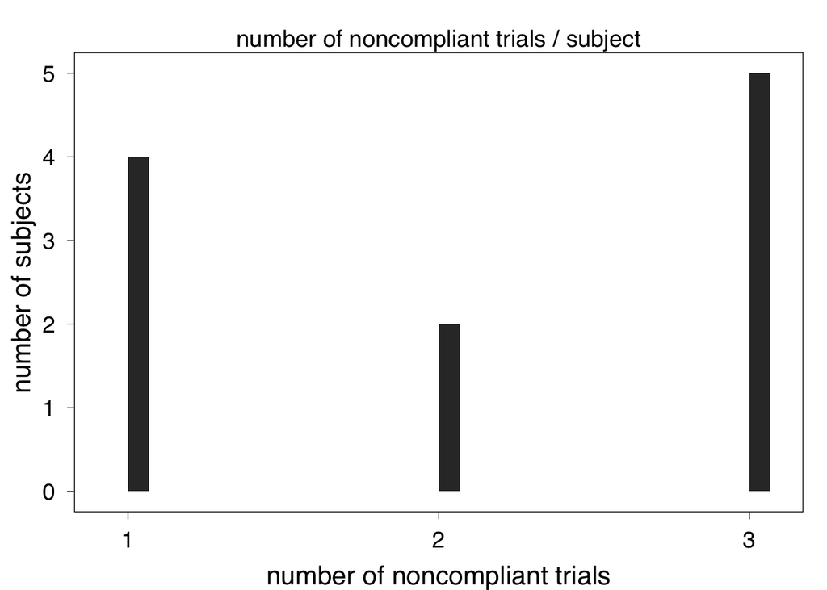

```r
qplot(data=data.frame(table(d.bad$workerid)), x=Freq, geom='histogram')+
  scale_x_continuous(breaks=seq(0:4))+
  ggtitle("number of noncompliant trials / subject")+
  xlab("number of noncompliant trials")+
  ylab("number of subjects")
```

```
## stat_bin: binwidth defaulted to range/30. Use 'binwidth = x' to adjust this.
```

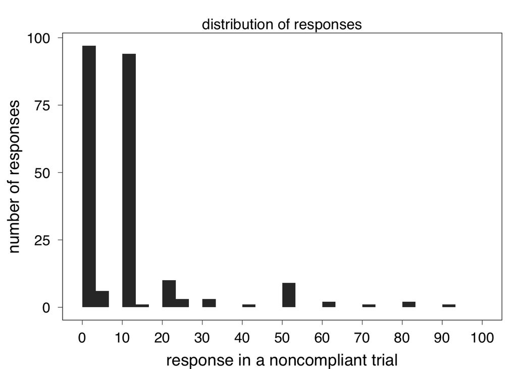

```r
d.bad<-d.bad %>% mutate(id = paste(workerid,trial))
d.tidy6<-d.tidy6%>% mutate(id = paste(workerid,trial))

d.culprits<-d.tidy6 %>% filter(id%in%d.bad$id)

qplot(data=d.culprits, x=value, geom='histogram')+
  scale_x_continuous(breaks=seq(0,100,10), limits=c(0,100))+
  ggtitle("distribution of responses")+
  xlab("response in a noncompliant trial")+
  ylab("number of responses")
```

# Prior 4: 5 sliders

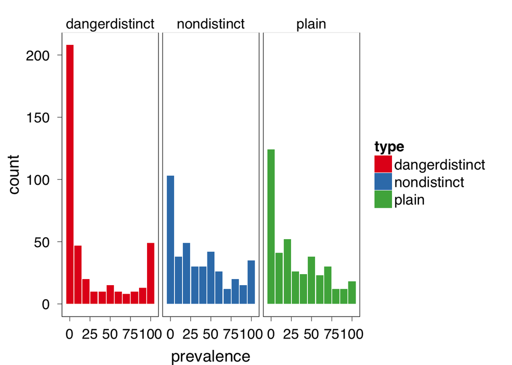

```r
d<-read.csv(file = '../data/cbg-prior4-trials.csv')
#head(d)
d.tidy4<- d%>%
  select(stim_type, starts_with("slider"), workerid, trial_num) %>%
  rename(context = stim_type,
          trial = trial_num) %>%
  gather(key, value, -context, -workerid, -trial)%>%
    mutate(roundval=round(value*10)*10)



d.tidy0<-data.frame(table(filter(d.tidy4,context=='bare')$roundval),
           table(filter(d.tidy4,context=='danger-distinct')$roundval),
           table(filter(d.tidy4,context=='nondistinctive')$roundval)) %>%
  select(Var1,Freq,Freq.1,Freq.2) %>%
  rename(prev=Var1,
         plain = Freq,
         dangerdistinct = Freq.1,
         nondistinct = Freq.2) %>%
  gather(type, value, -prev) %>%
  mutate(prev = to.n(prev))


d.tidy0$type<-factor(d.tidy0$type,
                       levels=c("dangerdistinct",
                                "nondistinct",
                                "plain"))

ggplot(d.tidy0, aes(x=prev, y=value, fill=type))+
  geom_bar(stat='identity', position=position_dodge())+
  facet_wrap(~type)+
  scale_fill_brewer(type='qual',palette='Set1')+
  xlab("prevalence")+
  ylab("count")
```

### Distinctive manipulation check

Does distinctive imply taboo? That is, if you rate one animal as having it, do you set all the others to 0? (compare with other types)

```
## stat_bin: binwidth defaulted to range/30. Use 'binwidth = x' to adjust this.
## stat_bin: binwidth defaulted to range/30. Use 'binwidth = x' to adjust this.
## stat_bin: binwidth defaulted to range/30. Use 'binwidth = x' to adjust this.
```

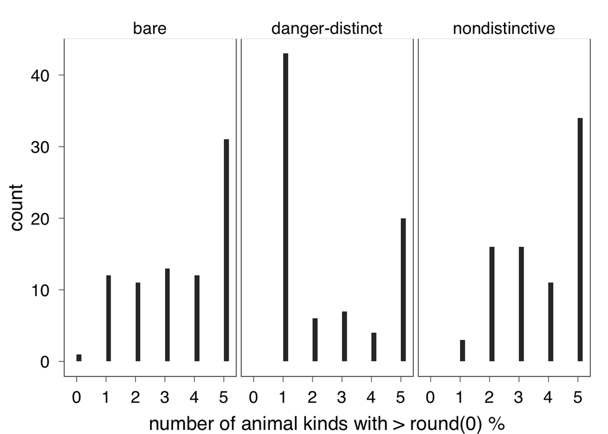

```r
d.taboo<-d.tidy4 %>%
  group_by(workerid,trial, context) %>%
  summarise(n.positive = sum(roundval>0))

qplot(data=d.taboo,x=n.positive,geom='histogram')+
  facet_wrap(~context)+
  xlab("number of animal kinds with > round(0) %")+
  scale_x_continuous(breaks = 0:5)
```

### Compliance

How much do subjects put for each trial? (What do their numbers sum to?)

“onedone” here means subject puts 100 for one of the animals, and all 0s otherwise

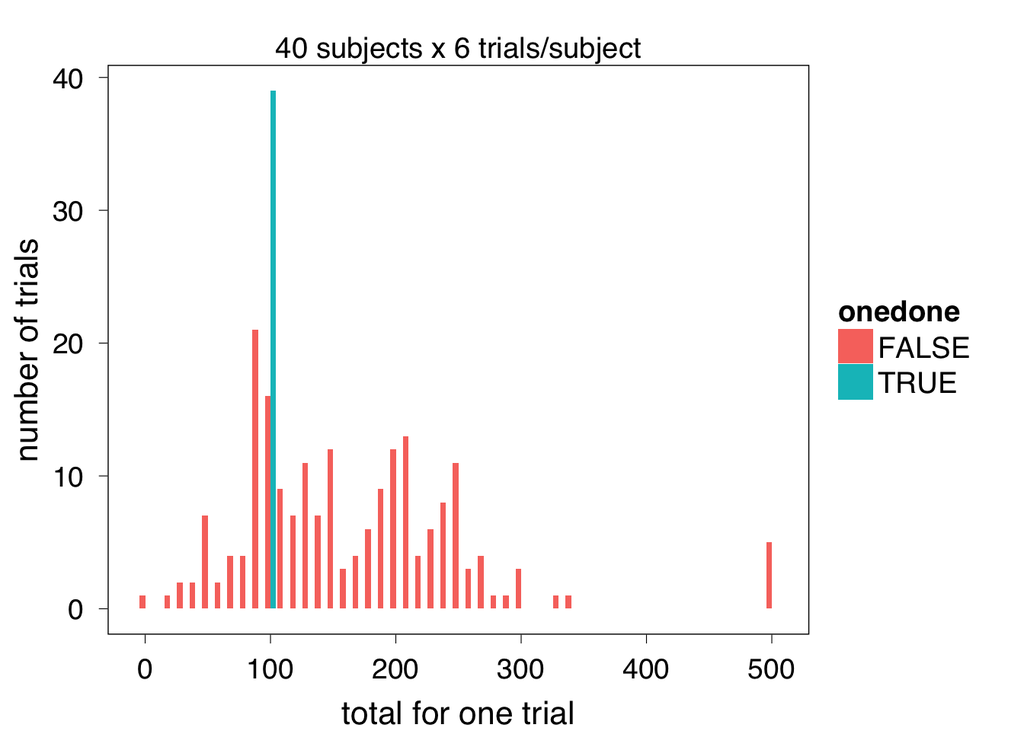

```r
d.subj <- d.tidy4 %>%
  group_by(workerid, trial) %>%
  summarise(total = sum(roundval), # rounds to the nearest 5
            max = max(roundval),
            min = min(roundval)) %>%
  mutate(onedone=((total==100)&(max==100)))

d.subj0<-data.frame(table(d.subj$total,d.subj$onedone)) %>%
  mutate(total = to.n(Var1)) %>%
  rename(onedone = Var2)

ggplot(data=d.subj0,aes(x=total,y=Freq, fill=onedone))+
  geom_bar(stat='identity',position=position_dodge())+
  xlab("total for one trial")+
  ylab("number of trials")+
  ggtitle("40 subjects x 6 trials/subject")
```

How many people make their responses add to 100?

```r
d.bad<-d.subj %>% filter((total==100)&(onedone==F))

print("number of subjects who do this 100 behavior at least once")
```

```
## [1] "number of subjects who do this 100 behavior at least once"
```

```r
length(levels(factor(d.bad$workerid)))
```

```
## [1] 12
```

```r
print("total number of trials with this 100 behavior")
```

```
## [1] "total number of trials with this 100 behavior"
```

```r
length(d.bad$workerid)
```

```
## [1] 16
```

```
## stat_bin: binwidth defaulted to range/30. Use 'binwidth = x' to adjust this.
```

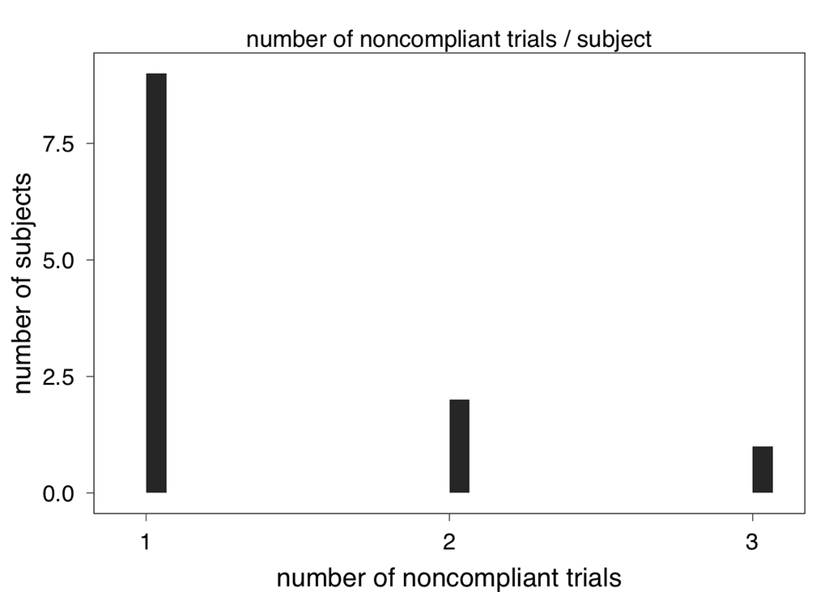

```r
qplot(data=data.frame(table(d.bad$workerid)), x=Freq, geom='histogram')+
  scale_x_continuous(breaks=seq(0:4))+
  ggtitle("number of noncompliant trials / subject")+
  xlab("number of noncompliant trials")+
  ylab("number of subjects")
```

```
## stat_bin: binwidth defaulted to range/30. Use 'binwidth = x' to adjust this.
```

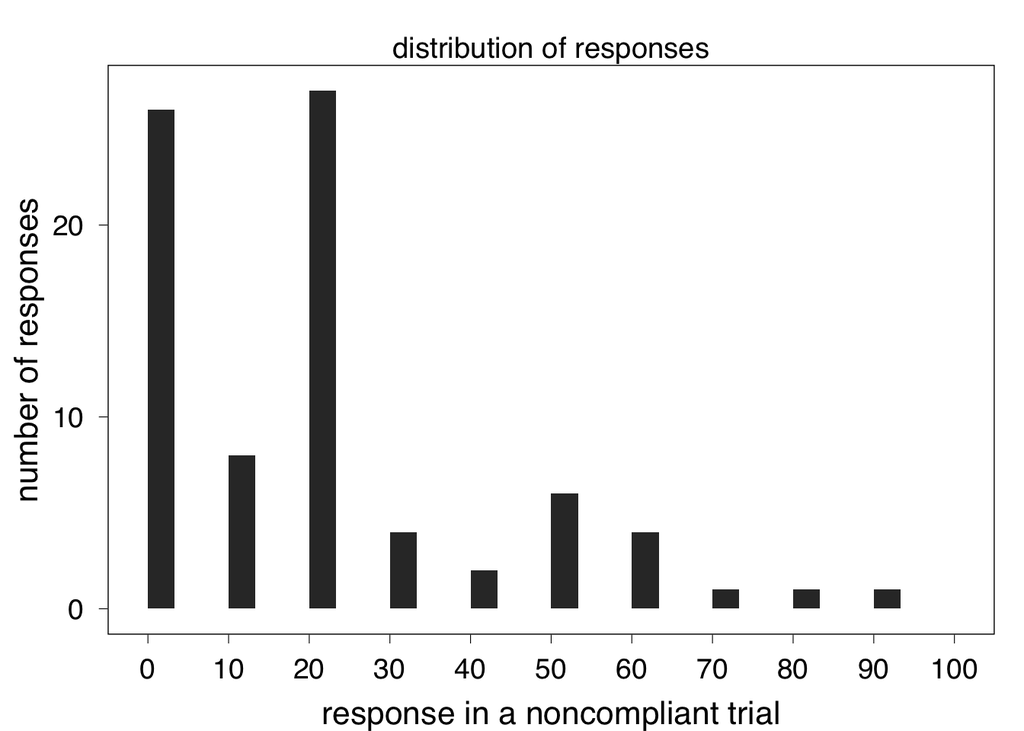

```r
d.bad<-d.bad %>% mutate(id = paste(workerid,trial))
d.tidy4<-d.tidy4%>% mutate(id = paste(workerid,trial))

d.culprits<-d.tidy4 %>% filter(id%in%d.bad$id)

qplot(data=d.culprits, x=roundval, geom='histogram')+
  scale_x_continuous(breaks=seq(0,100,10), limits=c(0,100))+
  ggtitle("distribution of responses")+
  xlab("response in a noncompliant trial")+
  ylab("number of responses")
```

# Prior 5: Accidental with 5 sliders

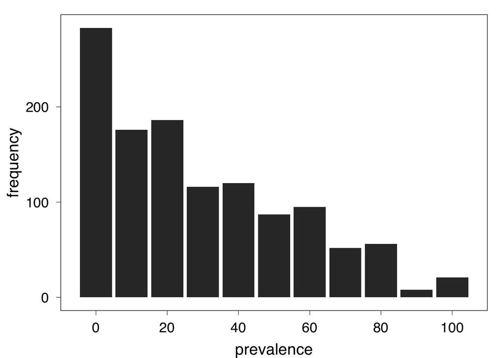

```r
d<-read.csv(file = '../data//cbg-prior5-trials.csv')
#head(d)
d.tidy5<- d%>%
  select(workerid, stim_type, starts_with("slider"), trial_num) %>%
  rename(context = stim_type,
         trial=trial_num) %>%
  gather(key, value, -context, -workerid, -trial)%>%
    mutate(roundval=round(value*10)*10)


d.sum<-data.frame(table(d.tidy5$roundval)) %>%
  mutate(Var1 = to.n(Var1))

ggplot(data=d.sum, aes(x=Var1,y=Freq))+
  geom_bar(stat='identity',position=position_dodge())+
  ylab('frequency')+
  xlab('prevalence')+
  scale_x_continuous(breaks=seq(0,100,20))
```

### Compliance

How much do subjects put for each trial? (What do their numbers sum to?)

“onedone” here means subject puts 100 for one of the animals, and all 0s otherwise

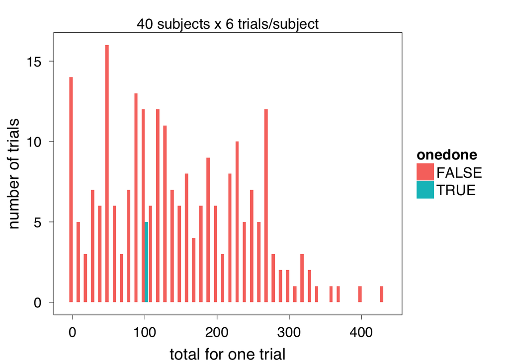

```r
d.subj <- d.tidy5 %>%
  group_by(workerid, trial) %>%
  summarise(total = sum(roundval), # rounds to the nearest 5
            max = max(roundval),
            min = min(roundval)) %>%
  mutate(onedone=((total==100)&(max==100)))

d.subj0<-data.frame(table(d.subj$total,d.subj$onedone)) %>%
  mutate(total = to.n(Var1)) %>%
  rename(onedone = Var2)

ggplot(data=d.subj0,aes(x=total,y=Freq, fill=onedone))+
  geom_bar(stat='identity',position=position_dodge())+
  xlab("total for one trial")+
  ylab("number of trials")+
  ggtitle("40 subjects x 6 trials/subject")
```

How many people make their responses add to 100?

```r
d.bad<-d.subj %>% filter((total==100)&(onedone==F))

print("number of subjects who do this 100 behavior at least once")
```

```
## [1] "number of subjects who do this 100 behavior at least once"
```

```r
length(levels(factor(d.bad$workerid)))
```

```
## [1] 7
```

```r
print("total number of trials with this 100 behavior")
```

```
## [1] "total number of trials with this 100 behavior"
```

```r
length(d.bad$workerid)
```

```
## [1] 12
```

```
## stat_bin: binwidth defaulted to range/30. Use 'binwidth = x' to adjust this.
```

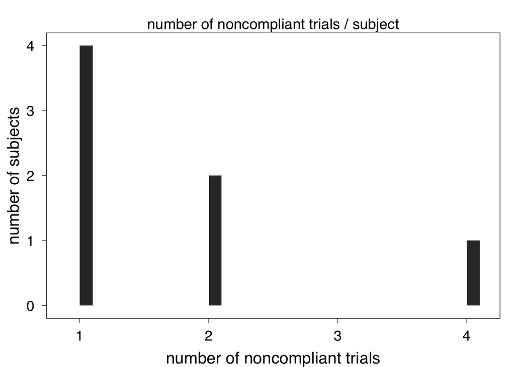

```r
qplot(data=data.frame(table(d.bad$workerid)), x=Freq, geom='histogram')+
  scale_x_continuous(breaks=seq(0:4))+
  ggtitle("number of noncompliant trials / subject")+
  xlab("number of noncompliant trials")+
  ylab("number of subjects")
```

```
## stat_bin: binwidth defaulted to range/30. Use 'binwidth = x' to adjust this.
```

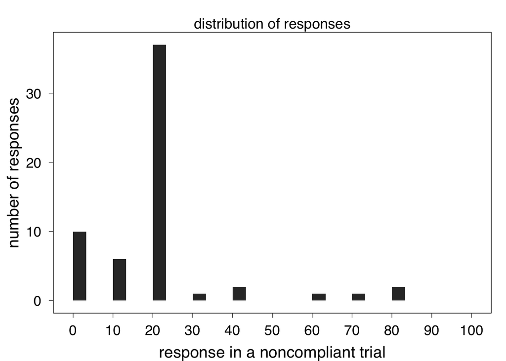

```r
d.bad<-d.bad %>% mutate(id = paste(workerid,trial))
d.tidy5<-d.tidy5%>% mutate(id = paste(workerid,trial))

d.culprits<-d.tidy5 %>% filter(id%in%d.bad$id)

qplot(data=d.culprits, x=roundval, geom='histogram')+
  scale_x_continuous(breaks=seq(0,100,10), limits=c(0,100))+
  ggtitle("distribution of responses")+
  xlab("response in a noncompliant trial")+
  ylab("number of responses")
```